# Exam 1 Output Packet

The goal of this analysis is to predict whether a person’s income was large (defined as more than $50k). The predictors include: age, workclass, education, education-num (number of years someone was in school), marital-status, occupation, relationship, race, sex, capital-gain, capital-loss, hours-per-week, native-country. The data was obtained from census data.

```r
pacman::p_load(DataExplorer, tidyverse, caret)
```

```
## 'data.frame':    48842 obs. of  14 variables:
##  $ age           : int  39 50 38 53 28 37 49 52 31 42 ...
##  $ workclass     : Factor w/ 8 levels "Federal-gov",..: 7 6 4 4 4 4 4 6 4 4 ...
##  $ education     : Ord.factor w/ 16 levels "Preschool"<"1st-4th"<..: 14 14 9 7 14 15 5 9 15 14 ...
##  $ education-num : int  13 13 9 7 13 14 5 9 14 13 ...
##  $ marital-status: Factor w/ 7 levels "Divorced","Married-AF-spouse",..: 5 3 1 3 3 3 4 3 5 3 ...
##  $ occupation    : Factor w/ 14 levels "Adm-clerical",..: 1 4 6 6 10 4 8 4 10 4 ...
##  $ relationship  : Factor w/ 6 levels "Husband","Not-in-family",..: 2 1 2 1 6 6 2 1 2 1 ...
##  $ race          : Factor w/ 5 levels "Amer-Indian-Eskimo",..: 5 5 5 3 3 5 3 5 5 5 ...
##  $ sex           : Factor w/ 2 levels "Female","Male": 2 2 2 2 1 1 1 2 1 2 ...
##  $ capital-gain  : int  2174 0 0 0 0 0 0 0 14084 5178 ...
##  $ capital-loss  : int  0 0 0 0 0 0 0 0 0 0 ...
##  $ hours-per-week: int  40 13 40 40 40 40 16 45 50 40 ...
##  $ native-country: Factor w/ 41 levels "Cambodia","Canada",..: 39 39 39 39 5 39 23 39 39 39 ...
##  $ income        : Ord.factor w/ 2 levels "small"<"large": 1 1 1 1 1 1 1 2 2 2 ...
```

## Part 1: Modeling

### Data Summary

Here is a summary of the target variable.

```r
prop.table(table(df$income))
```

```
##
##      small      large
## 0.96111975 0.03888025
```

```r
table(df$income)
```

```
##
## small large
## 24720  1000
```

Here is a summary of the data:

```
##                      mean          sd min   max median length missing
## age             37.073872   13.961843  17    90     35  25720       0
## education-num    9.670451    2.462841   1    16      9  25720       0
## capital-gain   281.427138 2885.241227   0 99999      0  25720       0
## capital-loss    59.064386  328.539716   0  4356      0  25720       0
## hours-per-week  39.103927   12.334345   1    99     40  25720       0
##                levels          mode missing
## workclass           8       Private    1669
## education          16       HS-grad       0
## marital-status      7 Never-married       0
## occupation         14  Adm-clerical    1676
## relationship        6       Husband       0
## race                5         White       0
## sex                 2          Male       0
## native-country     41 United-States     461
## income              2         small       0
```

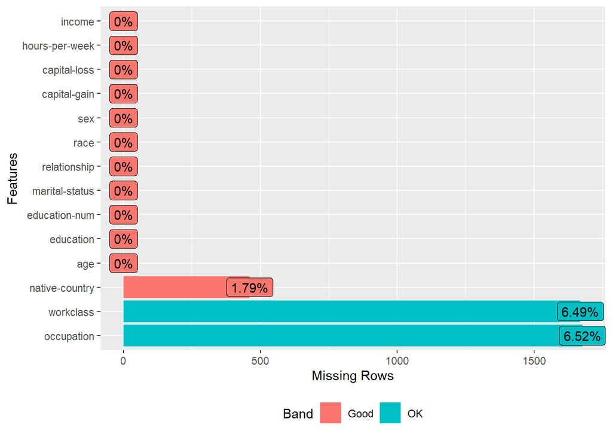

```r
plot_missing(df)
```

### Data Preperation

```r
table(df$education, df$`education-num`)
```

```
##
##                   1    2    3    4    5    6    7    8    9   10   11   12   13
##   Preschool      51    0    0    0    0    0    0    0    0    0    0    0    0
##   1st-4th         0  163    0    0    0    0    0    0    0    0    0    0    0
##   5th-6th         0    0  320    0    0    0    0    0    0    0    0    0    0
##   7th-8th         0    0    0  612    0    0    0    0    0    0    0    0    0
##   9th             0    0    0    0  488    0    0    0    0    0    0    0    0
##   10th            0    0    0    0    0  879    0    0    0    0    0    0    0
##   11th            0    0    0    0    0    0 1124    0    0    0    0    0    0
##   12th            0    0    0    0    0    0    0  403    0    0    0    0    0
##   HS-grad         0    0    0    0    0    0    0    0 9066    0    0    0    0
##   Prof-school     0    0    0    0    0    0    0    0    0    0    0    0    0
##   Assoc-acdm      0    0    0    0    0    0    0    0    0    0    0  845    0
##   Assoc-voc       0    0    0    0    0    0    0    0    0    0 1067    0    0
##   Some-college    0    0    0    0    0    0    0    0    0 6057    0    0    0
##   Bachelors       0    0    0    0    0    0    0    0    0    0    0    0 3426
##   Masters         0    0    0    0    0    0    0    0    0    0    0    0    0
##   Doctorate       0    0    0    0    0    0    0    0    0    0    0    0    0
##
##                  14   15   16
##   Preschool       0    0    0
##   1st-4th         0    0    0
##   5th-6th         0    0    0
##   7th-8th         0    0    0
##   9th             0    0    0
##   10th            0    0    0
##   11th            0    0    0
##   12th            0    0    0
##   HS-grad         0    0    0
##   Prof-school     0  204    0
##   Assoc-acdm      0    0    0
##   Assoc-voc       0    0    0
##   Some-college    0    0    0
##   Bachelors       0    0    0
##   Masters       873    0    0
##   Doctorate       0    0  142
```

Here is a summary of the native-country variable.

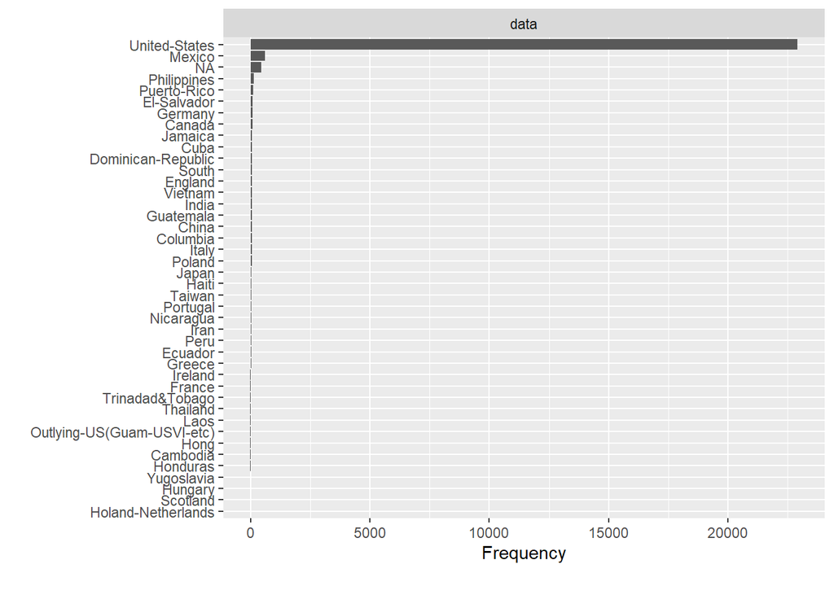

```r
library(DataExplorer)
plot_bar(df$`native-country`)
```

Summary of `marital-status_Married-AF-spouse`.

```r
summary(as.factor(df$`marital-status_Married-AF-spouse`))
```

```
##     0     1
## 25707    13
```

### Partitioning and Over-Sampling

Here are the proportions for the validation data set.

```r
set.seed(13)
trainIndex<-createDataPartition(df$income, p=0.8, list=FALSE, times=1)

valid<-df[-trainIndex,]
```

```r
prop.table(table(valid$income))
```

```
##
##      small      large
## 0.96111975 0.03888025
```

```r
dim(valid)
```

```
## [1] 5144   40
```

Here are the proportions for the training data set.

```r
prop.table(table(training$income))
```

```
##
## small large
##   0.5   0.5
```

### Modeling

I constructed some models.

### Compare the models

Model 1

```r
library(pROC)

r<-roc(valid$income, preds)
r$auc
```

```
## Area under the curve: 0.9004
```

Model 2

```r
r1<-roc(valid$income, preds1)
r1$auc
```

```
## Area under the curve: 0.8182
```

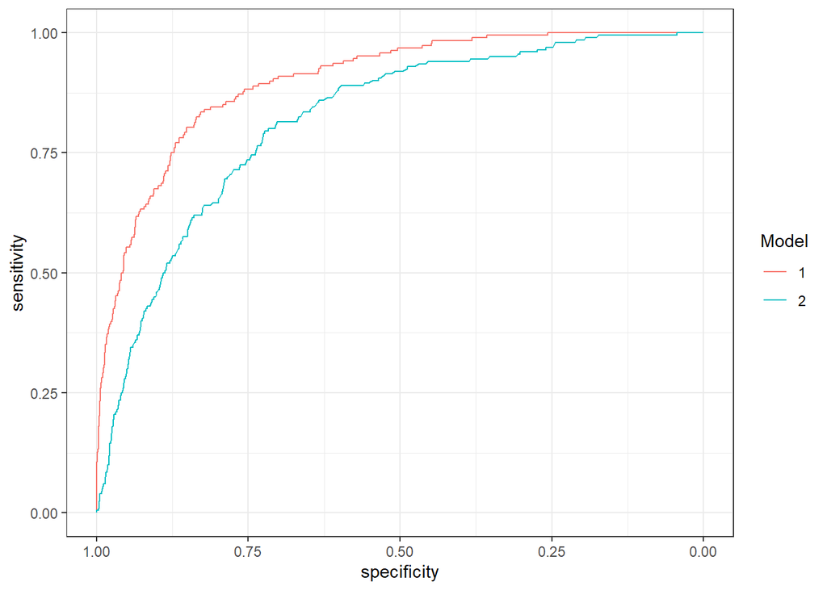

```r
roc<-list(r, r1)
p<-ggroc(roc)+theme_bw()+scale_colour_discrete("Model")
p
```

```r
coords(r1,"best", ret="threshold")
```

```
##   threshold
## 1 0.5012566
```

Here is a summary of the income variable in the validation data.

```r
summary(valid$income)
```

```
## small large
##  4944   200
```

```r
valid$preds<-preds
valid$cut1<-ifelse(valid$preds>0.501, 'large', 'small')
valid$cut1<-relevel(as.factor(valid$cut1), ref="large")
confusionMatrix(valid$cut1, valid$income)
```

[output not shown]

Below is a small summary from a lift analysis for model 1 on the validation data.

```
##       Cutoffs True_Positive Counts
## 96  0.9326007            53     95
## 97  0.9315382            53     96
## 98  0.9310702            53     97
## 99  0.9296657            53     98
## 100 0.9285023            53     99
```

## Part 2: PCA

Let’s pretend we are going to construct a model to predict Class, using only the first 4 columns in data (because this is an exam, not real life).

```r
library(mlbench)
data("Sonar")
Sonar<-Sonar[,1:4]
data.summary(Sonar)
```

```
##          mean         sd    min    max  median length missing
## V1 0.02916394 0.02299091 0.0015 0.1371 0.02280    208       0
## V2 0.03843654 0.03295993 0.0006 0.2339 0.03080    208       0
## V3 0.04383221 0.03842811 0.0015 0.3059 0.03430    208       0
## V4 0.05389231 0.04652796 0.0058 0.4264 0.04405    208       0
## data frame with 0 columns and 0 rows
```

```r
pca<-prcomp(Sonar,scale=T)
pca$rotation
```

```
##          PC1        PC2        PC3        PC4
## V1 0.4638718  0.6853104  0.5056565 -0.2438937
## V2 0.5244959  0.2658007 -0.5597689  0.5838774
## V3 0.5273907 -0.3233094 -0.3778910 -0.6888603
## V4 0.4812340 -0.5959620  0.5368134  0.3536587
```

```r
head(scale(Sonar))
```

```
##            V1         V2          V3         V4
## 1 -0.39858974 -0.0405504 -0.02686084 -0.7133841
## 2  0.70184499  0.4206156  1.05307772  0.3225521
## 3 -0.12891799  0.5996209  1.71925669  1.1693547
## 4 -0.83354417 -0.6473478  0.48058017 -0.7176825
## 5  2.04585419  0.8544758  0.11105902 -0.3114752
## 6 -0.02452892  0.2082365 -0.41980235 -0.7843091
```